# Team

Stephanie Femrite

2/9/2020

```r
choco <- read.csv("https://xdaiisu.github.io/ds202materials/hwlabs/choco.csv")
nrow(choco)
```

```
## [1] 1852
```

There were 1852 chocolate bars rated.

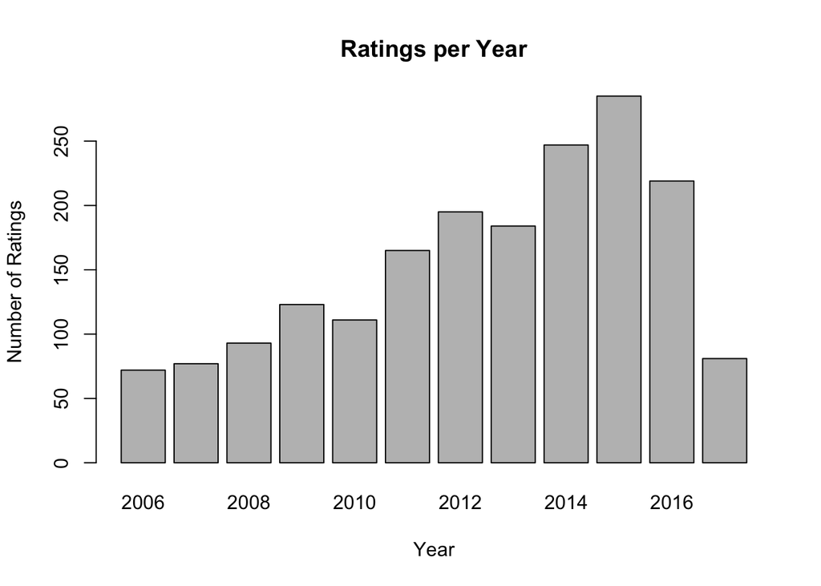

```r
rating <- choco$Rating
year <- choco$Review.Date
tab <- table(year)
chart <-as.data.frame(tab)
year <- (2006:2017)
barplot(chart$Freq, names.arg = year, main = 'Ratings per Year', xlab = 'Year', ylab = 'Number of Ratings')
```

```r
location <- table(choco$Company.Location)
locdf <- as.data.frame(location)
head(locdf[order(locdf$Freq, decreasing = TRUE),], 3)
```

```
##      Var1 Freq
## 58 U.S.A.  787
## 19 France  158
## 8  Canada  132
```

The 3 locations with the most ratings are the U.S.A, France, and Canada.

```r
topThree <- choco[choco$Company.Location == "U.S.A."| choco$Company.Location =="France"|choco$Company.Location =="Canada",]
avCount <- aggregate(topThree[,7], list(topThree$Company.Location), mean)
avCount
```

```
##   Group.1        x
## 1  Canada 3.312500
## 2  France 3.253165
## 3  U.S.A. 3.162325
```

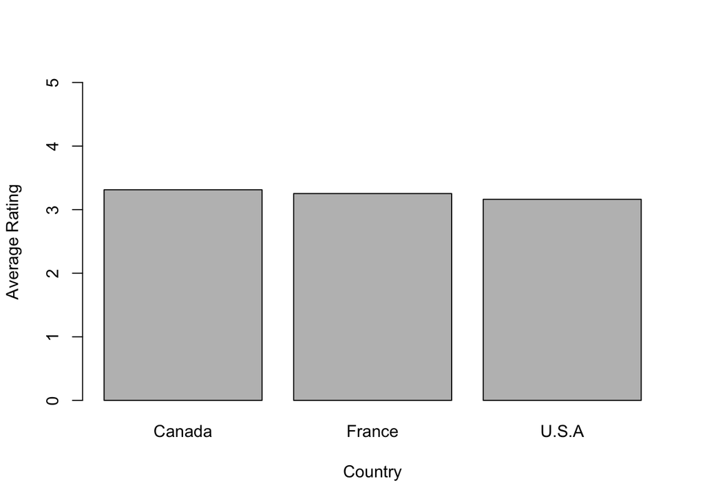

```r
barplot(avCount$x, names.arg=c("Canada", "France", "U.S.A"), xlab = "Country", ylab = "Average Rating", ylim = c(0,5))
```

The average rating for Canada is the highest at 3.31, followed by France at 3.25, and the US at 3.16.

4. How does bean type effect rating for the top 4 most common beans?

```r
beanFrame <- as.data.frame(table(choco$Bean.Type))

head(beanFrame[order(beanFrame$Freq, decreasing = TRUE),],5)
```

```
##                    Var1 Freq
## 1                        938
## 34           Trinitario  421
## 9               Criollo  153
## 21            Forastero   87
## 27 Forastero (Nacional)   52
```

The top four most common beans are the Trinitario, the Criollo, the Forastero, and the Forastero (Nacional). (the first row is blank because it’s the N/A values)

```r
topFour <- choco[choco$Bean.Type == "Trinitario" | choco$Bean.Type == "Criollo" | choco$Bean.Type == "Forastero"| choco$Bean.Type == "Forastero (Nacional)",]

avCount1 <- aggregate(topFour[,7], list(topFour$Bean.Type), mean)
avCount1
```

```
##                Group.1        x
## 1              Criollo 3.240196
## 2            Forastero 3.100575
## 3 Forastero (Nacional) 3.269231
## 4           Trinitario 3.244656
```

[figure not shown]

```r
barplot(avCount1$x, names.arg=c("Trinitario", "Criollo", "Forastero","Forastero (N)"), xlab = "Bean Type", ylab = "Average Rating", ylim = c(0,5))
```

The average ratings between bean types aren’t that different. Forastero (Nacional) is the highest with an average rating of 3.27, followed by Trinitario and Criollo with an average rating of 3.24, and then Forastero with an average rathing of 3.10.

6. Stephanie and I worked together at the library to complete all the parts of this project. We started using her computer but it was struggling to run RStudio so we switched to mine half way through.